# Manuscript Matcher Model Comparison

Joel Carlson

May 12, 2017

# Comparison Against Prod with Citations

The current production model allows the user to input citations along with the title and abstract text. The predictions from the model are considerably better when it is given citations. As can be seen below, the current production model achieves superior performance to the deep learning model when it is provided with citations. It should be noted, however, that in the dataset being used here, **more than 80% of the observations include citations**, however, based on the historical request/response data acquired from the endnote team, **only 7.67% of real requests included citations**. So while the current production algorithm performs well with citations, in the real world it is rarely provided this opportunity. The deep learning model performs on par with the prior dataset.

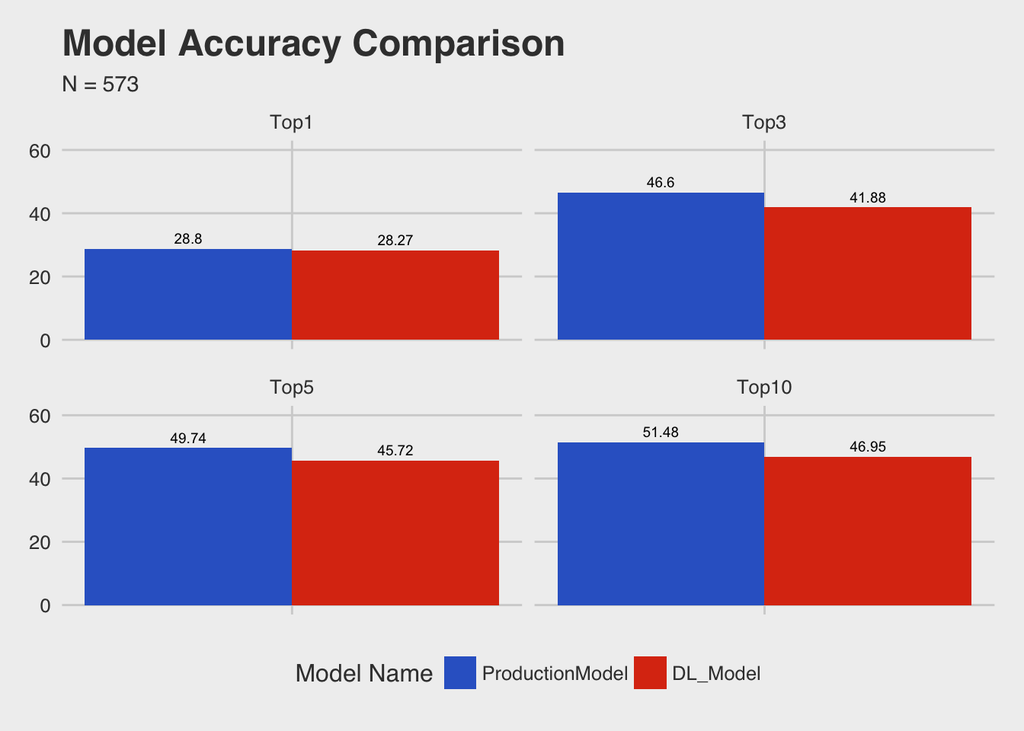

# Comparison Against Prod without Citations

Due to the mismatch between citation levels in this dataset, and real citation levels, I requested the **exact same requests**, but without citations included. Below are the results:

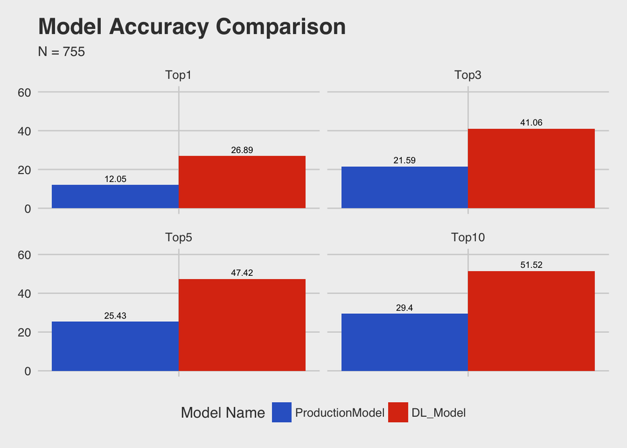

Interestingly, we can see that the model more frequently makes predictions when given data without citations (it made predictions on only 573 requests with citations, but 755 without) . This alters the accuracy of the deep learning model slightly, as we only allow it to return the number of predictions that the prod algorithm returns. In the real world, where citations are unlikely to be provided, the deep learning model is clearly superior.

# Weighted Comparison: 8% of requests include citations

There are a number of ways that this comparison could be performed. The simplest way would be to perform a single sampling to create a single dataset where 8% of the requests included citations (while ensuring there is no overlap between the abstracts). However, the best way would be a monte carlo style simulation, where we randomly sample each dataset such that the end result includes 8% citations, and perform this sampling a number of times. This is the approach that has been chosen below.

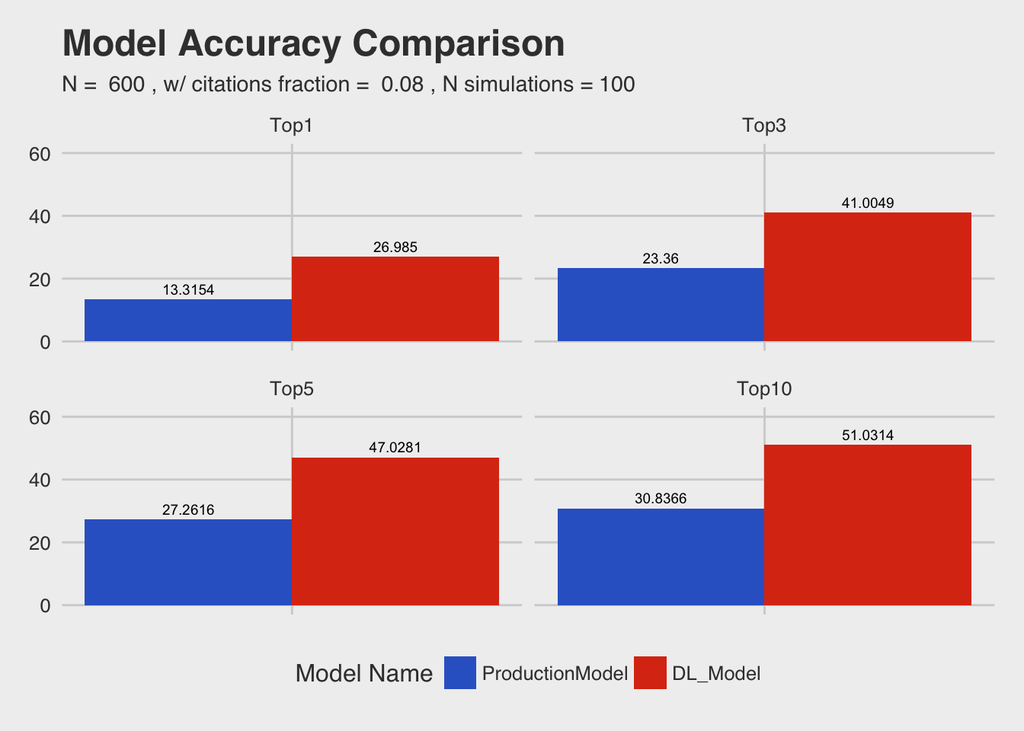